# Caso Práctico 06: BMW vs Volkswagen

Daniel Corral Ruiz

30-11-2020

## Objetivos informe

Utilizando datos diarios de los dos series desde el año 2014, debemos analizar la relación entre BMW y Volkswagen, contestando a las siguiente preguntas:

- ¿Estimar el modelo garch de BMW?
- ¿Están cointegradas?
- Plantear un modelo VAR mensual entre los dos activos.

## Carga de datos

Comenzamos cargando el dataset mediante la librería “quantmod”. Esta librería nos permite obtener la información financiera de empresas durante un periodo de tiempo determinado. Descargamos los datos de BMW y Volkswagen entre 2014-01-01 y 2020-11-20.

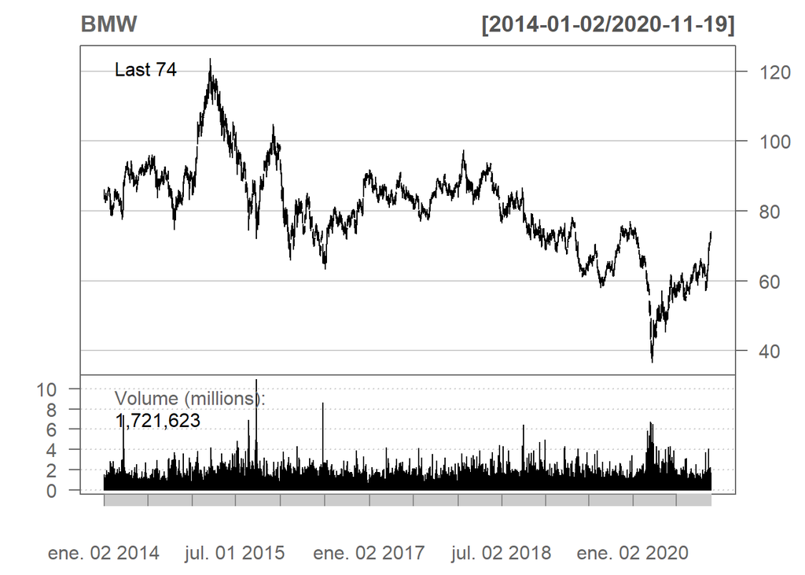

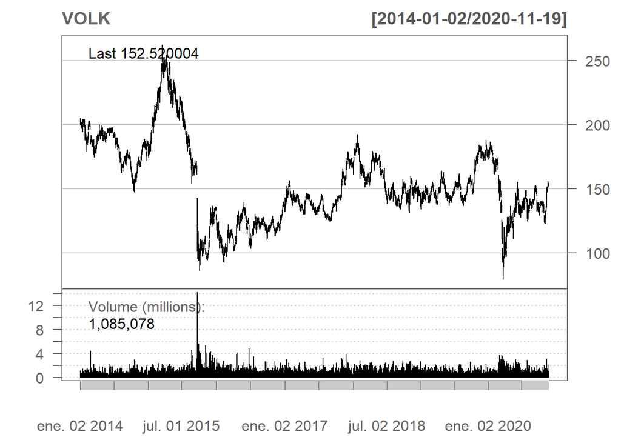

## Estimar el modelo GARCH BMW

A continuación mostramos el gráfico de BMW con el precio y la rentabilidad de sus acciones.

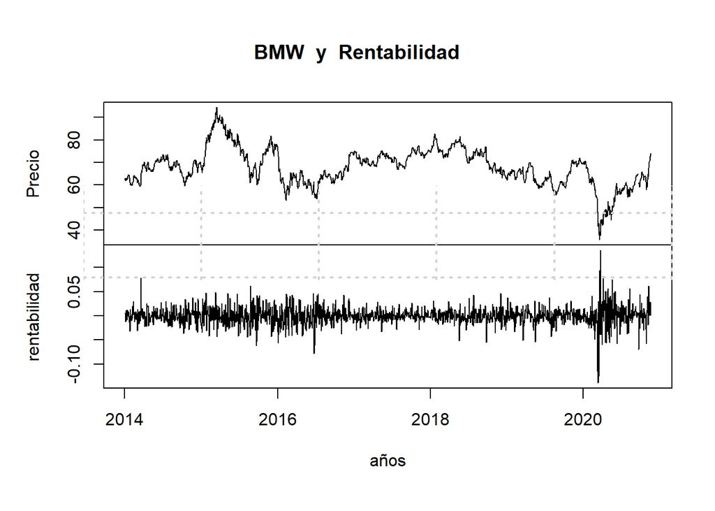

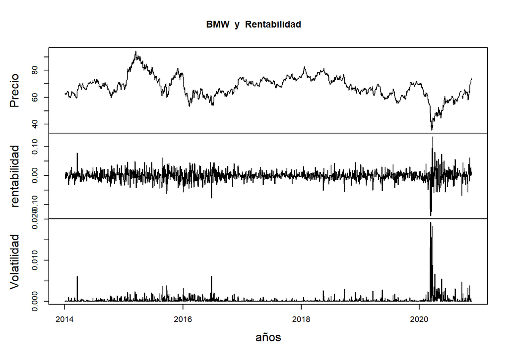

```
##
##  One Sample t-test
##
## data:  dRentContBMW
## t = -0.16339, df = 1742, p-value = 0.8702
## alternative hypothesis: true mean is not equal to 0
## 95 percent confidence interval:
##  -0.0009046861  0.0007655462
## sample estimates:
##     mean of x
## -6.956998e-05
```

Observamos un pvalor > 0.05, lo que aceptamos Ho y por lo tanto aceptamos que las medias de los grupos son iguales. La hipótesis nula de la prueba de Box Ljung, Ho, es que nuestro modelo no muestra falta de ajuste (o en términos simples, el modelo está bien). La hipótesis alternativa , H1 , es sólo que el modelo hace mostrar una falta de ajuste. Además se ha representado la volatilidad, rentabilidad y precio de BMW.

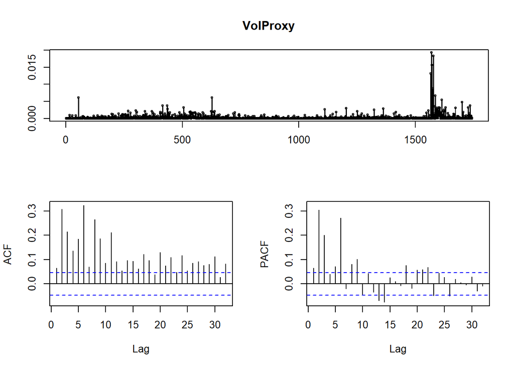

```
##
##  Box-Ljung test
##
## data:  VolProxy
## X-squared = 734.6, df = 10, p-value < 2.2e-16
```

```
##
##  Box-Ljung test
##
## data:  VolProxy
## X-squared = 947.57, df = 20, p-value < 2.2e-16
```

```
##
##  Box-Ljung test
##
## data:  VolProxy
## X-squared = 1162.6, df = 40, p-value < 2.2e-16
```

El modelo GARCH es un modelo autorregresivo generalizado que captura las agrupaciones de volatilidad de las rentabilidades a través de la varianza condicional.

En otras palabras, el modelo GARCH encuentra la volatilidad promedio a medio plazo mediante una autorregresión que depende de la suma de perturbaciones rezagadas y de la suma de varianzas rezagadas. El GARCH(1,1) es el modelo mas utilizado, en realidad es un ARMA(1,1) sobre la varianza de los errores.

```
##
## Title:
##  GARCH Modelling
##
## Call:
##  garchFit(formula = ~1 + garch(1, 0), data = dRentContBMW, trace = F)
##
## Mean and Variance Equation:
##  data ~ 1 + garch(1, 0)
## <environment: 0x000000002764e358>
##  [data = dRentContBMW]
##
## Conditional Distribution:
##  norm
##
## Coefficient(s):
##         mu       omega      alpha1
## 8.3594e-05  2.4105e-04  2.8597e-01
##
## Std. Errors:
##  based on Hessian
##
## Error Analysis:
##         Estimate  Std. Error  t value Pr(>|t|)
## mu     8.359e-05   3.991e-04    0.209    0.834
## omega  2.411e-04   1.088e-05   22.150  < 2e-16 ***
## alpha1 2.860e-01   4.513e-02    6.337 2.35e-10 ***
## ---
## Signif. codes:  0 '***' 0.001 '**' 0.01 '*' 0.05 '.' 0.1 ' ' 1
##
## Log Likelihood:
##  4593.466    normalized:  2.635379
##
## Description:
##  Mon Nov 30 17:27:02 2020 by user: danicorral
##
##
## Standardised Residuals Tests:
##                                 Statistic p-Value
##  Jarque-Bera Test   R    Chi^2  3656.144  0
##  Shapiro-Wilk Test  R    W      0.9353104 0
##  Ljung-Box Test     R    Q(10)  22.15973  0.01431123
##  Ljung-Box Test     R    Q(15)  31.55218  0.007404434
##  Ljung-Box Test     R    Q(20)  37.43376  0.01037614
##  Ljung-Box Test     R^2  Q(10)  328.6068  0
##  Ljung-Box Test     R^2  Q(15)  391.0757  0
##  Ljung-Box Test     R^2  Q(20)  482.6781  0
##  LM Arch Test       R    TR^2   233.1586  0
##
## Information Criterion Statistics:
##       AIC       BIC       SIC      HQIC
## -5.267316 -5.257913 -5.267322 -5.263839
```

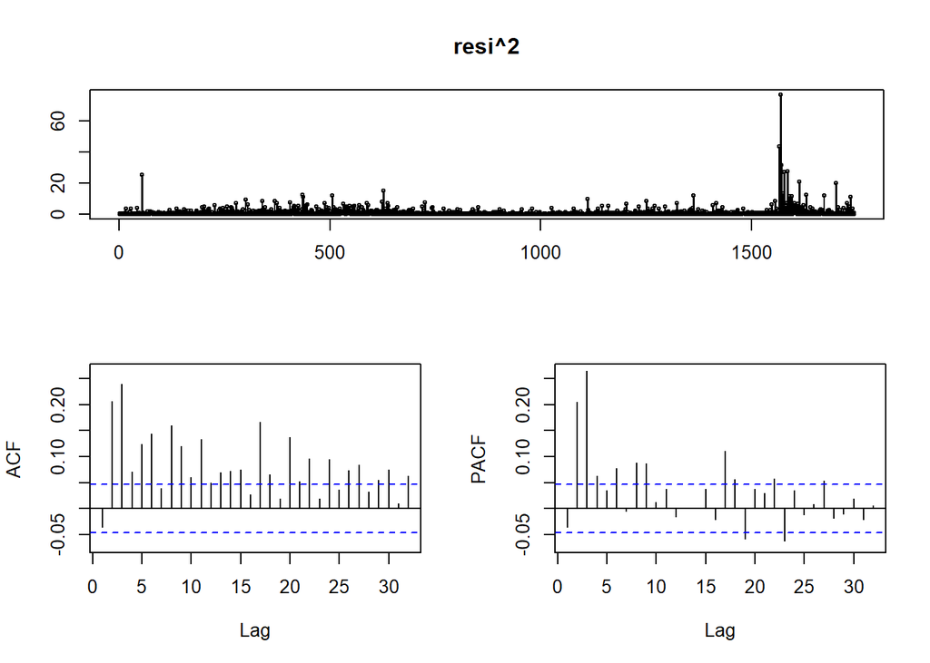

```
##
## Title:
##  GARCH Modelling
##
## Call:
##  garchFit(formula = ~1 + garch(1, 1), data = dRentContBMW, trace = F)
##
## Mean and Variance Equation:
##  data ~ 1 + garch(1, 1)
## <environment: 0x000000001eda8d38>
##  [data = dRentContBMW]
##
## Conditional Distribution:
##  norm
##
## Coefficient(s):
##         mu       omega      alpha1       beta1
## 1.0536e-04  3.1064e-06  4.7961e-02  9.4235e-01
##
## Std. Errors:
##  based on Hessian
##
## Error Analysis:
##         Estimate  Std. Error  t value Pr(>|t|)
## mu     1.054e-04   3.447e-04    0.306  0.75983
## omega  3.106e-06   1.159e-06    2.680  0.00737 **
## alpha1 4.796e-02   7.939e-03    6.041 1.53e-09 ***
## beta1  9.423e-01   1.022e-02   92.177  < 2e-16 ***
## ---
## Signif. codes:  0 '***' 0.001 '**' 0.01 '*' 0.05 '.' 0.1 ' ' 1
##
## Log Likelihood:
##  4759.311    normalized:  2.730529
##
## Description:
##  Mon Nov 30 17:27:02 2020 by user: danicorral
##
##
## Standardised Residuals Tests:
##                                 Statistic p-Value
##  Jarque-Bera Test   R    Chi^2  883.5951  0
##  Shapiro-Wilk Test  R    W      0.9681929 0
##  Ljung-Box Test     R    Q(10)  21.7978   0.01616848
##  Ljung-Box Test     R    Q(15)  27.50571  0.02487607
##  Ljung-Box Test     R    Q(20)  34.63149  0.02215708
##  Ljung-Box Test     R^2  Q(10)  19.35452  0.03598406
##  Ljung-Box Test     R^2  Q(15)  20.83343  0.1422362
##  Ljung-Box Test     R^2  Q(20)  23.08758  0.2845147
##  LM Arch Test       R    TR^2   19.61287  0.07477286
##
## Information Criterion Statistics:
##       AIC       BIC       SIC      HQIC
## -5.456467 -5.443929 -5.456478 -5.451832
```

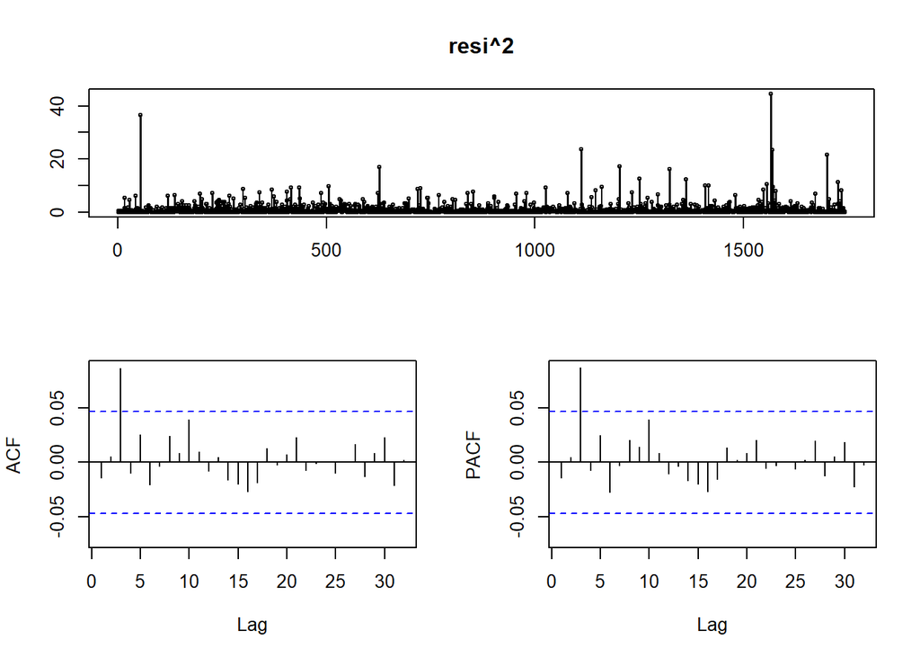

Obtenemos la predicción del modelo GARCH para BMW.

```
##
## Title:
##  GARCH Modelling
##
## Call:
##  garchFit(formula = ~1 + garch(1, 1), data = dRentContBMW, cond.dist = "std",
##     trace = F)
##
## Mean and Variance Equation:
##  data ~ 1 + garch(1, 1)
## <environment: 0x0000000027c434b8>
##  [data = dRentContBMW]
##
## Conditional Distribution:
##  std
##
## Coefficient(s):
##          mu        omega       alpha1        beta1        shape
## -5.5004e-05   2.0093e-06   4.5422e-02   9.5048e-01   4.6659e+00
##
## Std. Errors:
##  based on Hessian
##
## Error Analysis:
##          Estimate  Std. Error  t value Pr(>|t|)
## mu     -5.500e-05   3.107e-04   -0.177    0.859
## omega   2.009e-06   1.002e-06    2.004    0.045 *
## alpha1  4.542e-02   9.792e-03    4.639 3.51e-06 ***
## beta1   9.505e-01   1.028e-02   92.441  < 2e-16 ***
## shape   4.666e+00   5.401e-01    8.640  < 2e-16 ***
## ---
## Signif. codes:  0 '***' 0.001 '**' 0.01 '*' 0.05 '.' 0.1 ' ' 1
##
## Log Likelihood:
##  4840.888    normalized:  2.777331
##
## Description:
##  Mon Nov 30 17:27:03 2020 by user: danicorral
##
##
## Standardised Residuals Tests:
##                                 Statistic p-Value
##  Jarque-Bera Test   R    Chi^2  925.3233  0
##  Shapiro-Wilk Test  R    W      0.9676547 0
##  Ljung-Box Test     R    Q(10)  22.13153  0.01444837
##  Ljung-Box Test     R    Q(15)  27.7025   0.02350721
##  Ljung-Box Test     R    Q(20)  34.89876  0.02065015
##  Ljung-Box Test     R^2  Q(10)  22.18176  0.01420494
##  Ljung-Box Test     R^2  Q(15)  23.56364  0.07288393
##  Ljung-Box Test     R^2  Q(20)  25.84654  0.1709401
##  LM Arch Test       R    TR^2   22.44995  0.0327757
##
## Information Criterion Statistics:
##       AIC       BIC       SIC      HQIC
## -5.548925 -5.533252 -5.548941 -5.543130
```

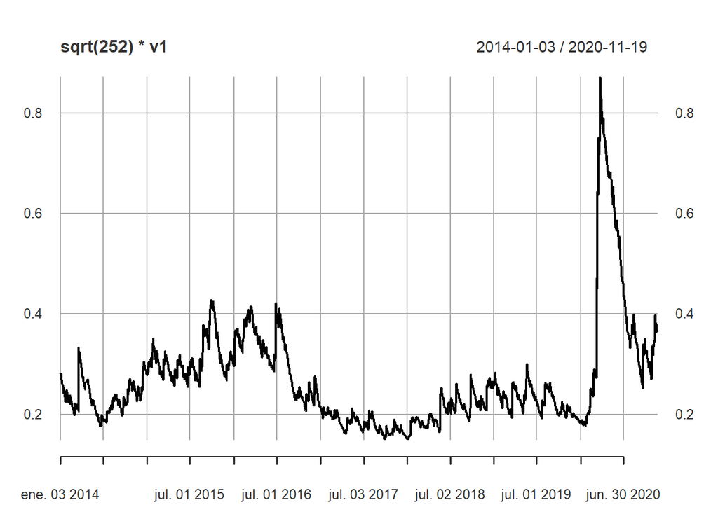

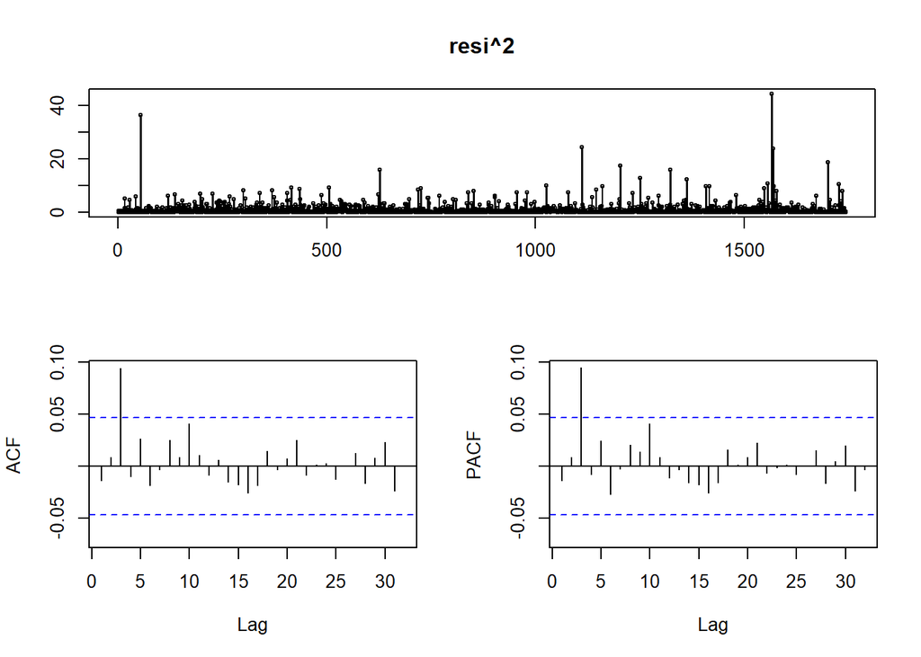

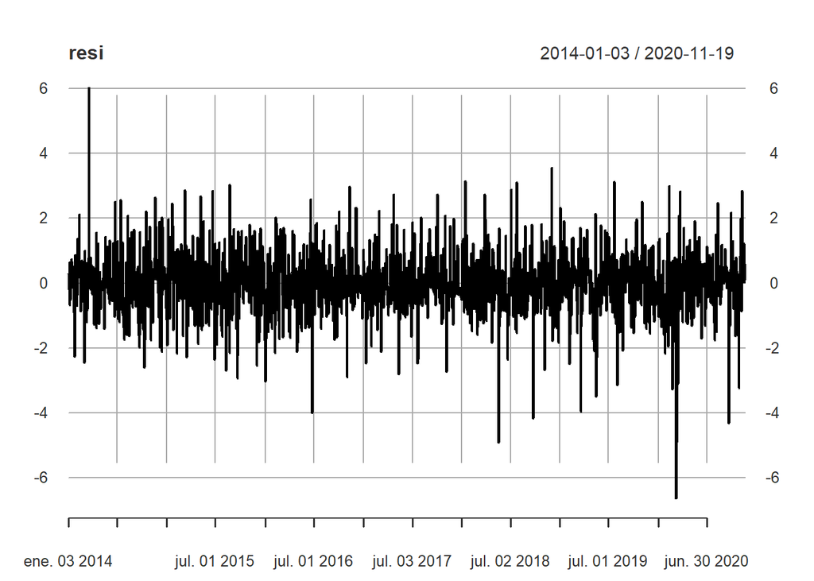

| meanForecast | meanError | standardDeviation |
| --- | --- | --- |
| -5.500396e-05 | 0.02235983 | 0.02235983 |
| -5.500396e-05 | 0.02235898 | 0.02235898 |
| -5.500396e-05 | 0.02235813 | 0.02235813 |
| -5.500396e-05 | 0.02235729 | 0.02235729 |
| -5.500396e-05 | 0.02235645 | 0.02235645 |
| -5.500396e-05 | 0.02235561 | 0.02235561 |
| -5.500396e-05 | 0.02235478 | 0.02235478 |
| -5.500396e-05 | 0.02235395 | 0.02235395 |
| -5.500396e-05 | 0.02235312 | 0.02235312 |
| -5.500396e-05 | 0.02235229 | 0.02235229 |

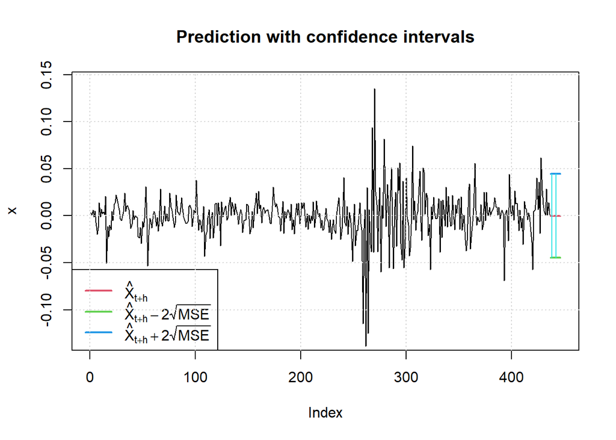

| meanForecast | meanError | standardDeviation | lowerInterval | upperInterval |
| --- | --- | --- | --- | --- |
| -5.500396e-05 | 0.02235983 | 0.02235983 | -0.04477467 | 0.04466466 |
| -5.500396e-05 | 0.02235898 | 0.02235898 | -0.04477296 | 0.04466296 |
| -5.500396e-05 | 0.02235813 | 0.02235813 | -0.04477127 | 0.04466126 |
| -5.500396e-05 | 0.02235729 | 0.02235729 | -0.04476958 | 0.04465957 |
| -5.500396e-05 | 0.02235645 | 0.02235645 | -0.04476790 | 0.04465789 |
| -5.500396e-05 | 0.02235561 | 0.02235561 | -0.04476622 | 0.04465622 |
| -5.500396e-05 | 0.02235478 | 0.02235478 | -0.04476456 | 0.04465455 |
| -5.500396e-05 | 0.02235395 | 0.02235395 | -0.04476290 | 0.04465289 |
| -5.500396e-05 | 0.02235312 | 0.02235312 | -0.04476124 | 0.04465123 |
| -5.500396e-05 | 0.02235229 | 0.02235229 | -0.04475959 | 0.04464959 |

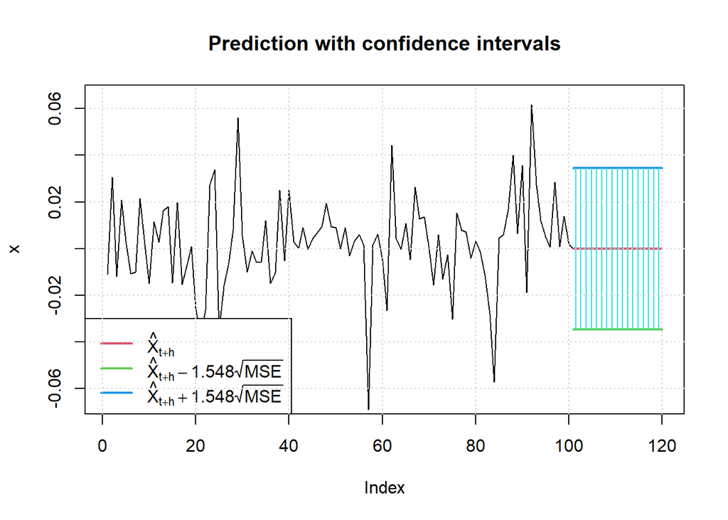

| meanForecast | meanError | standardDeviation | lowerInterval | upperInterval |
| --- | --- | --- | --- | --- |
| -5.500396e-05 | 0.02235983 | 0.02235983 | -0.03465833 | 0.03454832 |
| -5.500396e-05 | 0.02235898 | 0.02235898 | -0.03465701 | 0.03454700 |
| -5.500396e-05 | 0.02235813 | 0.02235813 | -0.03465570 | 0.03454569 |
| -5.500396e-05 | 0.02235729 | 0.02235729 | -0.03465439 | 0.03454438 |
| -5.500396e-05 | 0.02235645 | 0.02235645 | -0.03465309 | 0.03454308 |
| -5.500396e-05 | 0.02235561 | 0.02235561 | -0.03465180 | 0.03454179 |
| -5.500396e-05 | 0.02235478 | 0.02235478 | -0.03465051 | 0.03454050 |
| -5.500396e-05 | 0.02235395 | 0.02235395 | -0.03464922 | 0.03453921 |
| -5.500396e-05 | 0.02235312 | 0.02235312 | -0.03464794 | 0.03453793 |
| -5.500396e-05 | 0.02235229 | 0.02235229 | -0.03464666 | 0.03453666 |

[output cut: 10 more lines]

## Plantear un modelo VAR mensual entre los dos activos.

Una limitación con los modelos que hemos considerado hasta ahora es que imponen una relación unidireccional. La variable dependiente está influenciada por las variables predictoras (independientes, pero no viceversa. Sin embargo, hay muchos casos en los que también se debe permitir lo contrario, donde todas las variables se afectan entre sí. Tales relaciones de retroalimentación (bidirecionalidad) se modelizancon los vectores autorregresivos (VAR). En un VAR, todas las variables son tratadas simétricamente. Todos ellos son modelizados como si se influyeran entre sí por igual. En una terminología más formal, todas las variables son ahora tratadas como “endógenas”.

```
## $selection
## AIC(n)  HQ(n)  SC(n) FPE(n)
##      1      1      1      1
##
## $criteria
##                    1             2             3             4             5
## AIC(n) -1.027091e+01 -1.026427e+01 -1.018196e+01 -1.009523e+01 -1.001417e+01
## HQ(n)  -1.019589e+01 -1.013923e+01 -1.000691e+01 -9.870156e+00 -9.739087e+00
## SC(n)  -1.008266e+01 -9.950510e+00 -9.742697e+00 -9.530456e+00 -9.323898e+00
## FPE(n)  3.462891e-05  3.487145e-05  3.789160e-05  4.138032e-05  4.496849e-05
##                    6             7             8             9            10
## AIC(n) -1.004351e+01 -1.002932e+01 -9.981617e+00 -9.910458e+00 -9.946144e+00
## HQ(n)  -9.718409e+00 -9.654200e+00 -9.556483e+00 -9.435308e+00 -9.420978e+00
## SC(n)  -9.227731e+00 -9.088034e+00 -8.914828e+00 -8.718164e+00 -8.628345e+00
## FPE(n)  4.380184e-05  4.461463e-05  4.705431e-05  5.088488e-05  4.954017e-05
```

```
##
## VAR Estimation Results:
## =========================
## Endogenous variables: BMW, VOLK
## Deterministic variables: const
## Sample size: 82
## Log Likelihood: 200.966
## Roots of the characteristic polynomial:
## 0.2883 0.2883
## Call:
## VAR(y = vY)
##
##
## Estimation results for equation BMW:
## ====================================
## BMW = BMW.l1 + VOLK.l1 + const
##
##          Estimate Std. Error t value Pr(>|t|)
## BMW.l1   0.280649   0.164325   1.708  0.09158 .
## VOLK.l1 -0.354018   0.124637  -2.840  0.00573 **
## const    0.005696   0.008559   0.666  0.50765
## ---
## Signif. codes:  0 '***' 0.001 '**' 0.01 '*' 0.05 '.' 0.1 ' ' 1
##
##
## Residual standard error: 0.07748 on 79 degrees of freedom
## Multiple R-Squared: 0.09503, Adjusted R-squared: 0.07212
## F-statistic: 4.148 on 2 and 79 DF,  p-value: 0.01937
##
##
## Estimation results for equation VOLK:
## =====================================
## VOLK = BMW.l1 + VOLK.l1 + const
##
##          Estimate Std. Error t value Pr(>|t|)
## BMW.l1   0.518407   0.210225   2.466   0.0158 *
## VOLK.l1 -0.357848   0.159451  -2.244   0.0276 *
## const    0.004729   0.010950   0.432   0.6670
## ---
## Signif. codes:  0 '***' 0.001 '**' 0.01 '*' 0.05 '.' 0.1 ' ' 1
##
##
## Residual standard error: 0.09912 on 79 degrees of freedom
## Multiple R-Squared: 0.07649, Adjusted R-squared: 0.05311
## F-statistic: 3.272 on 2 and 79 DF,  p-value: 0.04314
##
##
##
## Covariance matrix of residuals:
##           BMW     VOLK
## BMW  0.006002 0.005613
## VOLK 0.005613 0.009824
##
## Correlation matrix of residuals:
##        BMW  VOLK
## BMW  1.000 0.731
## VOLK 0.731 1.000
```

```
##
## VAR Estimation Results:
## =========================
## Endogenous variables: BMW, VOLK
## Deterministic variables: none
## Sample size: 82
## Log Likelihood: 200.733
## Roots of the characteristic polynomial:
## 0.2881 0.2881
## Call:
## VAR(y = vY, type = "none")
##
##
## Estimation results for equation BMW:
## ====================================
## BMW = BMW.l1 + VOLK.l1
##
##         Estimate Std. Error t value Pr(>|t|)
## BMW.l1    0.2830     0.1637   1.729  0.08772 .
## VOLK.l1  -0.3543     0.1242  -2.852  0.00552 **
## ---
## Signif. codes:  0 '***' 0.001 '**' 0.01 '*' 0.05 '.' 0.1 ' ' 1
##
##
## Residual standard error: 0.07721 on 80 degrees of freedom
## Multiple R-Squared: 0.0945,  Adjusted R-squared: 0.07186
## F-statistic: 4.174 on 2 and 80 DF,  p-value: 0.01886
##
##
## Estimation results for equation VOLK:
## =====================================
## VOLK = BMW.l1 + VOLK.l1
##
##         Estimate Std. Error t value Pr(>|t|)
## BMW.l1    0.5204     0.2091   2.489   0.0149 *
## VOLK.l1  -0.3581     0.1586  -2.257   0.0267 *
## ---
## Signif. codes:  0 '***' 0.001 '**' 0.01 '*' 0.05 '.' 0.1 ' ' 1
##
##
## Residual standard error: 0.09861 on 80 degrees of freedom
## Multiple R-Squared: 0.07673, Adjusted R-squared: 0.05365
## F-statistic: 3.324 on 2 and 80 DF,  p-value: 0.04104
##
##
##
## Covariance matrix of residuals:
##           BMW     VOLK
## BMW  0.005927 0.005543
## VOLK 0.005543 0.009701
##
## Correlation matrix of residuals:
##        BMW  VOLK
## BMW  1.000 0.731
## VOLK 0.731 1.000
```

```
## $Granger
##
##  Granger causality H0: BMW do not Granger-cause VOLK
##
## data:  VAR object model.var1
## F-Test = 6.193, df1 = 1, df2 = 160, p-value = 0.01385
##
##
## $Instant
##
##  H0: No instantaneous causality between: BMW and VOLK
##
## data:  VAR object model.var1
## Chi-squared = 28.594, df = 1, p-value = 8.927e-08
```

```
##
## Impulse response coefficients
## $BMW
##                 BMW          VOLK
##  [1,]  7.720553e-02  7.215505e-02
##  [2,] -3.713073e-03  1.433906e-02
##  [3,] -6.130922e-03 -7.066521e-03
##  [4,]  7.684115e-04 -6.600561e-04
##  [5,]  4.513166e-04  6.362027e-04
##  [6,] -9.766679e-05  7.048114e-06
##  [7,] -3.013800e-05 -5.334655e-05
##  [8,]  1.037028e-05  3.418754e-06
##  [9,]  1.723723e-06  4.172239e-06
## [10,] -9.903139e-07 -5.969695e-07
## [11,] -6.877614e-08 -3.015742e-07
```

[output cut: 74 more lines]

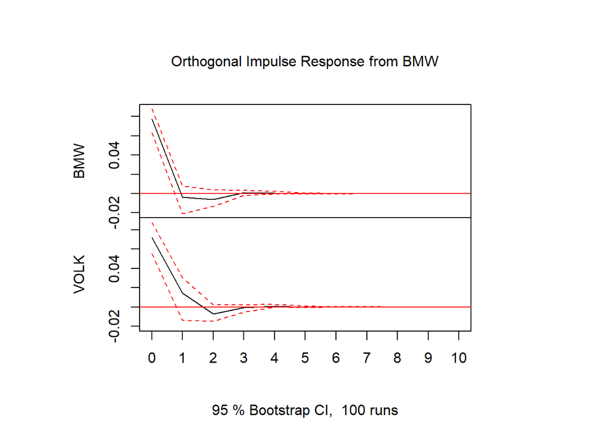

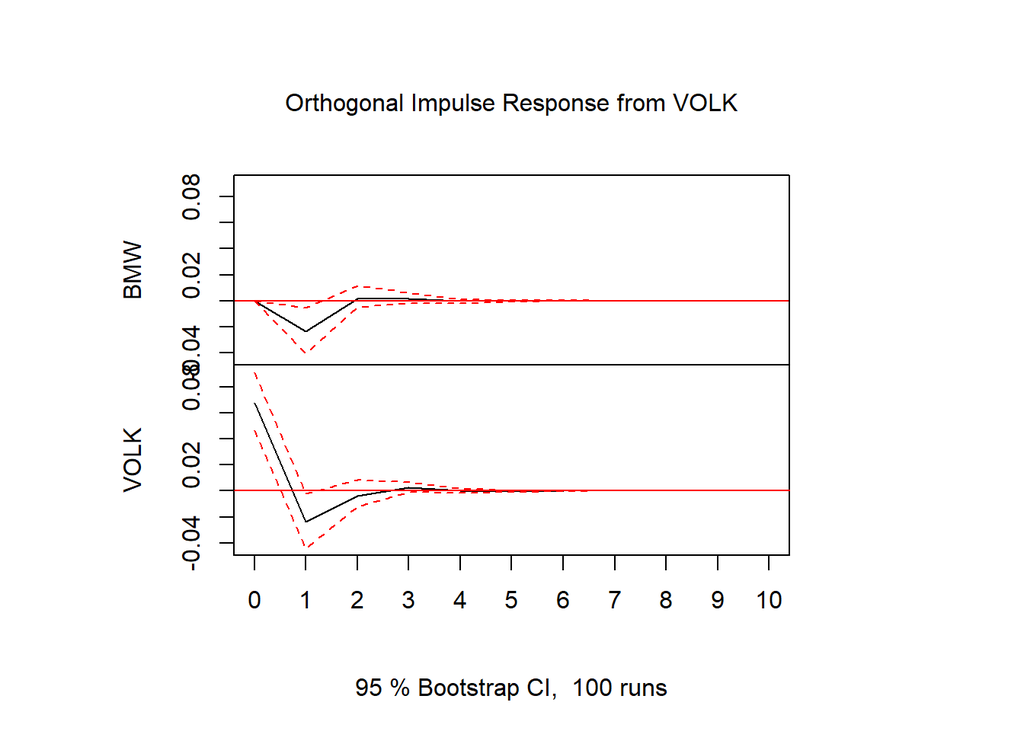

```
## $BMW
##               fcst      lower     upper        CI
## [1,] -3.765025e-03 -0.1550851 0.1475550 0.1513201
## [2,] -2.139204e-02 -0.1799135 0.1371294 0.1585214
## [3,]  1.918137e-03 -0.1570967 0.1609330 0.1590148
## [4,]  1.632003e-03 -0.1574310 0.1606950 0.1590630
## [5,] -2.817326e-04 -0.1593481 0.1587847 0.1590664
## [6,] -1.143436e-04 -0.1591811 0.1589524 0.1590667
## [7,]  3.197142e-05 -0.1590348 0.1590987 0.1590668
## [8,]  7.093218e-06 -0.1590597 0.1590739 0.1590668
##
## $VOLK
##               fcst      lower     upper        CI
## [1,]  5.737372e-02 -0.1359006 0.2506480 0.1932743
## [2,] -2.250286e-02 -0.2234255 0.1784198 0.2009227
## [3,] -3.074230e-03 -0.2046095 0.1984610 0.2015353
## [4,]  2.098922e-03 -0.1994901 0.2036879 0.2015890
## [5,]  9.768947e-05 -0.2014954 0.2016907 0.2015930
## [6,] -1.815845e-04 -0.2017750 0.2014118 0.2015934
## [7,]  5.518521e-06 -0.2015879 0.2015990 0.2015935
## [8,]  1.466096e-05 -0.2015788 0.2016081 0.2015935
```